# Dhairya Kothari

#### Implement a multi-layer perceptron to classify the MNIST data that we have been working with all semester. Use MLPClassifier in sklearn.

```python
from scipy.stats import mode
import numpy as np
#from mnist import MNIST
from time import time
import pandas as pd
import os
import matplotlib.pyplot as matplot
import matplotlib
%matplotlib inline

import random
matplot.rcdefaults()
from time import time
from IPython.display import display, HTML
from itertools import chain
from sklearn.metrics import confusion_matrix
from sklearn.metrics import accuracy_score
import seaborn as sb
from sklearn.model_selection import ParameterGrid
from sklearn.neural_network import MLPClassifier
import warnings
warnings.filterwarnings('ignore')
```

```python
from tensorflow.examples.tutorials.mnist import input_data
mnist = input_data.read_data_sets('MNIST_data/')
```

```
Extracting MNIST_data/train-images-idx3-ubyte.gz
Extracting MNIST_data/train-labels-idx1-ubyte.gz
Extracting MNIST_data/t10k-images-idx3-ubyte.gz
Extracting MNIST_data/t10k-labels-idx1-ubyte.gz
```

```python
train = mnist.train.images
validation = mnist.validation.images
test = mnist.test.images

trlab = mnist.train.labels
vallab = mnist.validation.labels
tslab = mnist.test.labels

train = np.concatenate((train, validation), axis=0)
trlab = np.concatenate((trlab, vallab), axis=0)
```

```python
mlp = MLPClassifier()
mlp.fit(train, trlab)
```

```
MLPClassifier(activation='relu', alpha=0.0001, batch_size='auto', beta_1=0.9,
       beta_2=0.999, early_stopping=False, epsilon=1e-08,
       hidden_layer_sizes=(100,), learning_rate='constant',
       learning_rate_init=0.001, max_iter=200, momentum=0.9,
       nesterovs_momentum=True, power_t=0.5, random_state=None,
       shuffle=True, solver='adam', tol=0.0001, validation_fraction=0.1,
       verbose=False, warm_start=False)
```

```python
accuracy_score(tslab, mlp.predict(test)) # Test Accuracy
```

```
0.9778
```

#### (a) Find a good combination of parameter values for the MLPClassifier that provides the best accuracy on the 10,000 test images. Describe your parameter choices and why you believe these values are good choices.

We choose Alpha and Max_iter as the parameter to run the model on and select the best from those.

According to Scikit Learn- MLP classfier documentation,  
Alpha is L2 or ridge penalty (regularization term) parameter.  
Max_iter is Maximum number of iterations, the solver iterates until convergence.  
So, these ones makes sense as we could see some changing values of accuracy while tuning them,

```python
i = 0
df = pd.DataFrame(columns = ['alpha','max_iter','train_acc','test_acc','train_time'])
for a in [0.00001,0.0001,0.001,0.01, 0.1, 1, 10]:
    for mi in [10,100,200,500,1000,2000]:
        st = time()
        mlp = MLPClassifier(alpha=a, max_iter=mi)
        mlp.fit(train, trlab)
        end = time() - st

        acc_tr = accuracy_score(trlab, mlp.predict(train)) # Train Accuracy
        acc = accuracy_score(tslab, mlp.predict(test)) # Test Accuracy
        df.loc[i] = [a,mi,acc_tr,acc,end]
        i=i+1
```

```python
df # Results
```

|  | alpha | max_iter | train_acc | test_acc | train_time |
| --- | --- | --- | --- | --- | --- |
| 0 | 0.00001 | 10.0 | 0.989533 | 0.9751 | 9.513362 |
| 1 | 0.00001 | 100.0 | 1.000000 | 0.9792 | 35.246778 |
| 2 | 0.00001 | 200.0 | 0.999950 | 0.9782 | 35.320454 |
| 3 | 0.00001 | 500.0 | 1.000000 | 0.9787 | 42.534170 |
| 4 | 0.00001 | 1000.0 | 0.999650 | 0.9764 | 35.734075 |
| 5 | 0.00001 | 2000.0 | 0.999983 | 0.9781 | 39.468011 |
| 6 | 0.00010 | 10.0 | 0.989417 | 0.9758 | 9.325813 |
| 7 | 0.00010 | 100.0 | 0.999900 | 0.9782 | 35.416230 |
| 8 | 0.00010 | 200.0 | 0.992400 | 0.9709 | 44.222664 |
| 9 | 0.00010 | 500.0 | 0.998633 | 0.9764 | 40.425065 |
| 10 | 0.00010 | 1000.0 | 0.994300 | 0.9728 | 38.569622 |
| 11 | 0.00010 | 2000.0 | 0.999983 | 0.9776 | 43.423535 |
| 12 | 0.00100 | 10.0 | 0.988950 | 0.9743 | 9.373941 |
| 13 | 0.00100 | 100.0 | 0.999950 | 0.9781 | 33.523193 |
| 14 | 0.00100 | 200.0 | 0.999917 | 0.9795 | 31.724409 |
| 15 | 0.00100 | 500.0 | 0.999633 | 0.9752 | 42.274478 |
| 16 | 0.00100 | 1000.0 | 0.999400 | 0.9778 | 31.284236 |
| 17 | 0.00100 | 2000.0 | 1.000000 | 0.9782 | 37.767680 |
| 18 | 0.01000 | 10.0 | 0.987850 | 0.9761 | 9.285706 |
| 19 | 0.01000 | 100.0 | 0.999000 | 0.9779 | 36.310609 |
| 20 | 0.01000 | 200.0 | 0.998700 | 0.9771 | 43.446597 |
| 21 | 0.01000 | 500.0 | 0.999167 | 0.9779 | 36.770835 |
| 22 | 0.01000 | 1000.0 | 0.999500 | 0.9796 | 40.686252 |
| 23 | 0.01000 | 2000.0 | 0.997367 | 0.9775 | 36.911208 |
| 24 | 0.10000 | 10.0 | 0.983750 | 0.9731 | 9.193460 |
| 25 | 0.10000 | 100.0 | 0.990917 | 0.9787 | 32.303950 |
| 26 | 0.10000 | 200.0 | 0.992667 | 0.9802 | 33.043918 |
| 27 | 0.10000 | 500.0 | 0.991667 | 0.9787 | 37.553917 |
| 28 | 0.10000 | 1000.0 | 0.992283 | 0.9779 | 33.461008 |
| 29 | 0.10000 | 2000.0 | 0.991833 | 0.9797 | 36.753789 |
| 30 | 1.00000 | 10.0 | 0.953550 | 0.9536 | 9.187445 |
| 31 | 1.00000 | 100.0 | 0.957850 | 0.9568 | 25.442695 |
| 32 | 1.00000 | 200.0 | 0.959267 | 0.9581 | 26.905587 |
| 33 | 1.00000 | 500.0 | 0.957533 | 0.9601 | 24.393637 |
| 34 | 1.00000 | 1000.0 | 0.958333 | 0.9589 | 25.306217 |
| 35 | 1.00000 | 2000.0 | 0.958250 | 0.9568 | 43.656156 |
| 36 | 10.00000 | 10.0 | 0.882517 | 0.8880 | 9.103221 |
| 37 | 10.00000 | 100.0 | 0.877850 | 0.8825 | 20.827414 |
| 38 | 10.00000 | 200.0 | 0.881017 | 0.8848 | 22.719449 |
| 39 | 10.00000 | 500.0 | 0.882133 | 0.8890 | 15.773970 |
| 40 | 10.00000 | 1000.0 | 0.880600 | 0.8878 | 15.246566 |
| 41 | 10.00000 | 2000.0 | 0.883083 | 0.8910 | 24.275589 |

#### (b) Using the parameters you found in part (a) present a plot that compares the test accuracy vs. the number of nodes in the hidden layer. Comment on your results.

As we can see that Model number 26 gives the best testing accuracy so parameters we select are  
Parameters:  
Alpha = 0.1  
Max Iterations = 200

```python
acc = []
acc_tr = []
timelog = []
for l in [10,20,50,100,200,500,1000]:
    t = time()
    mlp = MLPClassifier(alpha=0.1, max_iter=200, hidden_layer_sizes=(l,))
    mlp.fit(train, trlab)
    endt = time() - t

    a_tr = accuracy_score(trlab, mlp.predict(train)) # Train Accuracy
    a = accuracy_score(tslab, mlp.predict(test)) # Test Accuracy

    acc_tr.append(a_tr)
    acc.append(a)
    timelog.append(endt)
```

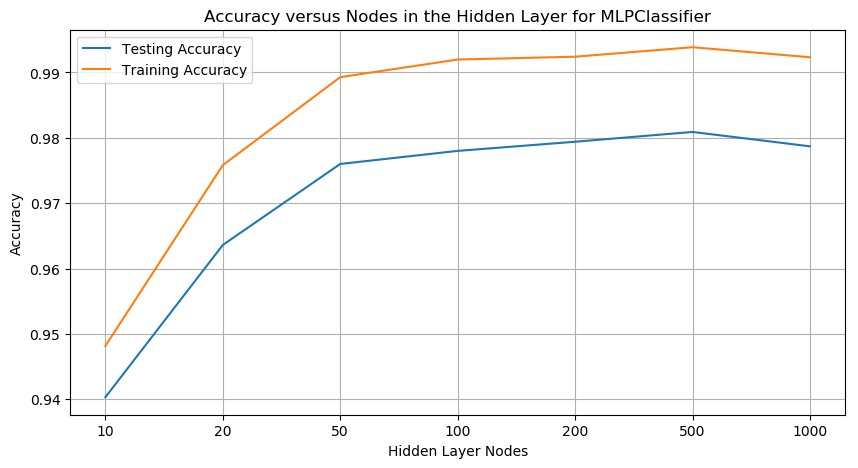

```python
l = [10,20,50,100,200,500,1000]
N = len(l)
l2 = np.arange(N)
matplot.subplots(figsize=(10, 5))
matplot.plot(l2, acc, label="Testing Accuracy")
matplot.plot(l2, acc_tr, label="Training Accuracy")
matplot.xticks(l2,l)
matplot.grid(True)
matplot.xlabel("Hidden Layer Nodes")
matplot.ylabel("Accuracy")
matplot.legend()
matplot.title('Accuracy versus Nodes in the Hidden Layer for MLPClassifier', fontsize=12)
matplot.show()
```

#### Inferences from the graph:

- So as we go from left to right on this graph, the bias decreases and variance increases
- As the nodes increases there is an increase in accuracy
- That stops at 500 nodes, then we see overfitting kicking in
- The accuracy drops after the nodes increases above 500 in the hidden layer
- Giving us the optimum nodes = 500 for this problem
- From the below graph, we can also see that as the nodes increases naturally the time increases as well

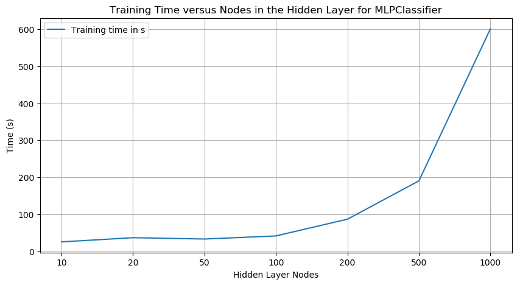

```python
l = [10,20,50,100,200,500,1000]
N = len(l)
l2 = np.arange(N)
matplot.subplots(figsize=(10, 5))
matplot.plot(l2, timelog, label="Training time in s")
matplot.xticks(l2,l)
matplot.grid(True)
matplot.xlabel("Hidden Layer Nodes")
matplot.ylabel("Time (s)")
matplot.legend()
matplot.title('Training Time versus Nodes in the Hidden Layer for MLPClassifier', fontsize=12)
matplot.show()
```

Final model parameters for highest test accuracy:  
Alpha = 0.1  
Max Iterations = 200  
Hidden Layer Nodes = 500

#### (c) How does the accuracy of your MLP classifier compare to what you found with KNN, Naïve Bayes, Logistic Regression, and SVM on this data set? How does the training time of the MLP classifier compare to the others?

Accuracy listed belongs to the best parameters in each model.

[output not shown]

*Note: the training time to be taken with a grain of salt as all the times reported from the previous models were run on different systems and are either the average or best case times for those models.

Regardless of the time inconsistencies in measuring, MLP is still miles ahead of all the other models in terms of magnitude of time and also in Accuracy.

#### ------------------------------------------- X -------------------------------------------